# Assignment-2

Author

Group-036

## Task 1 - Slate Health Check

This is a high-level overview of the financial health and composition of the studios historical slate.

Some cleaning has been done to prepare the data for this report. Some films in the dataset had missing or unrealistically low values for budget or revenue. Most dollar amounts in the dataset have been entered as the whole figure, but in some cases it appears they have been recorded as hundreds of thousands or millions of dollars. For example, *Escape from Tomorrow* has a recorded budget of 650 in the dataset. The film’s actual reported budget was $650,000.

Given the large initial size of the dataset (no. of films = 4803) we decided to filter out any films with budget or revenue amounts less than 1000 to cut films with missing or implausible values. We also removed any films with a reported budget higher than 550 million USD (the largest budget ever reported for a film). The franchise tag is not used for any film pre-1974 even when films *were* part of a franchise (like James Bond); given the importance of comparison between Original and Franchise films to this report we have also filtered for only films released in 1974 or later.

This left us with 3060 films to analyse, of which franchise films made up 7.22% of the films in our cleaned dataset, vs the 5.41% they made up in the original dataset. We are happy that this does not represent a large enough change in the composition of our data to skew our analysis.

### Summary of data

**Note 1: Coding for Original vs Franchise**

First films in a franchise are labelled as “Original” rather than as part of a franchise, and are therefore included in the data for the “Original” variable (see Table 1, where *Paranormal Activity* is an Original film, and *Paranormal Activity 2* is a Franchise film.)

Additionally, some films that are clearly part of a franchise are not labelled as such; i.e. all 4 Pirates of the Caribbean movies are labelled as Original movies.

As such, the figures in Table 1 should be taken as *indicative* of overall trends only, not treated as absolute truths.

Table 1: Summary statistics for the historical slate

| Statistic | Franchise | Original |
| --- | --- | --- |
| Number of movies | 221 | 2839 |
| Most Common Genre | Action (n = 63) | Drama (n = 681) |
| Mean Production Budget (USD millions) | 65.15 | 40.88 |
| Median Production Budget (USD millions) | 40 | 27 |
| Production Budget Standard Deviation (USD millions) | 63.2 | 42.48 |
| Mean Return on Investment (ROI) | 4.84 | 11.05 |
| Median ROI | 3.36 | 2.13 |
| ROI Standard Deviation | 6.11 | 254.93 |
| Max Production Budget (USD millions) | 280 | 380 |
|  | *(Avengers: Age of Ultron)* | *(Pirates of the Caribbean: On Stranger Tides)* |
| Minimum Production Budget (USD) | 852,510 | 7,000 |
|  | *(4 Months, 3 Weeks and 2 Days)* | *(Primer)* |
| Best ROI | 59.17 | 12890.39 |
|  | *(Paranormal Activity 2)* | *(Paranormal Activity)* |
| Worst ROI | 0 | 0 |
|  | *(5 Days of War)* | *(The Adventurer: The Curse of the Midas Box)* |

### Budget and ROI plots

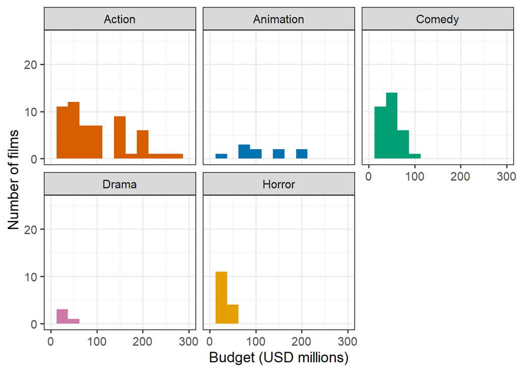

(a) Budget: Franchise films

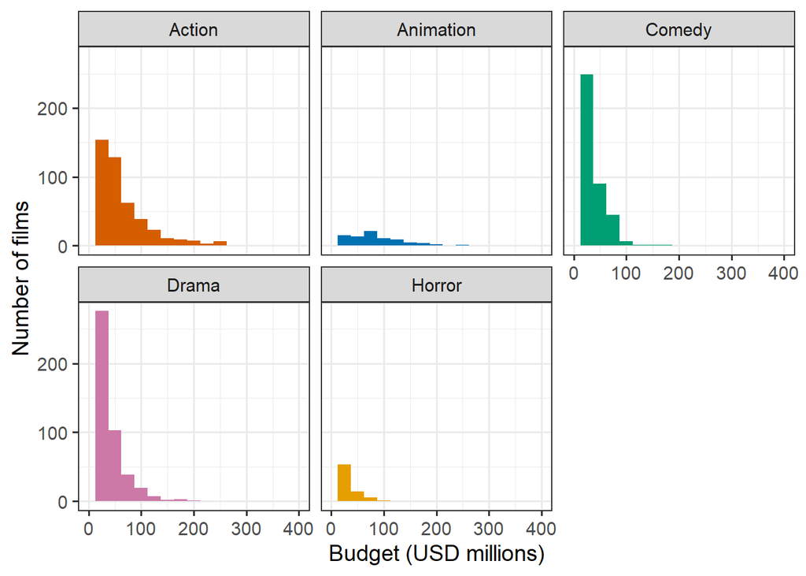

(b) Budget: Original films

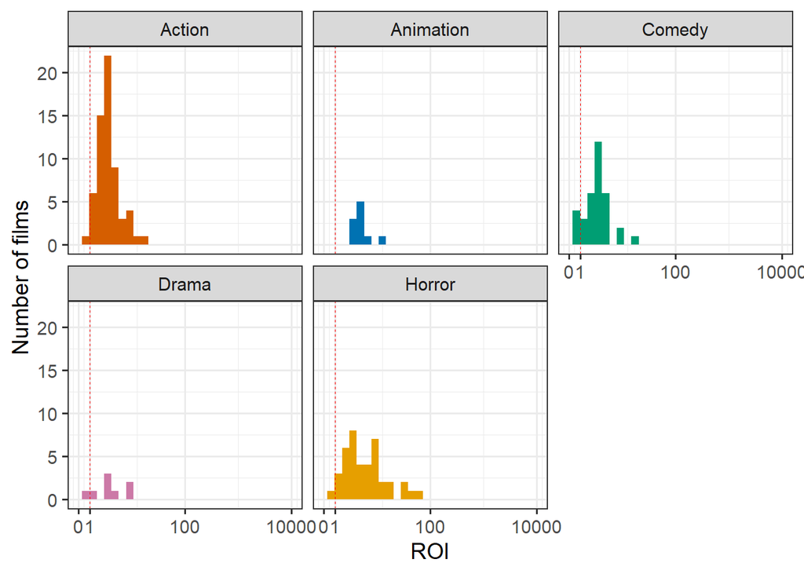

(c) ROI: Franchise films

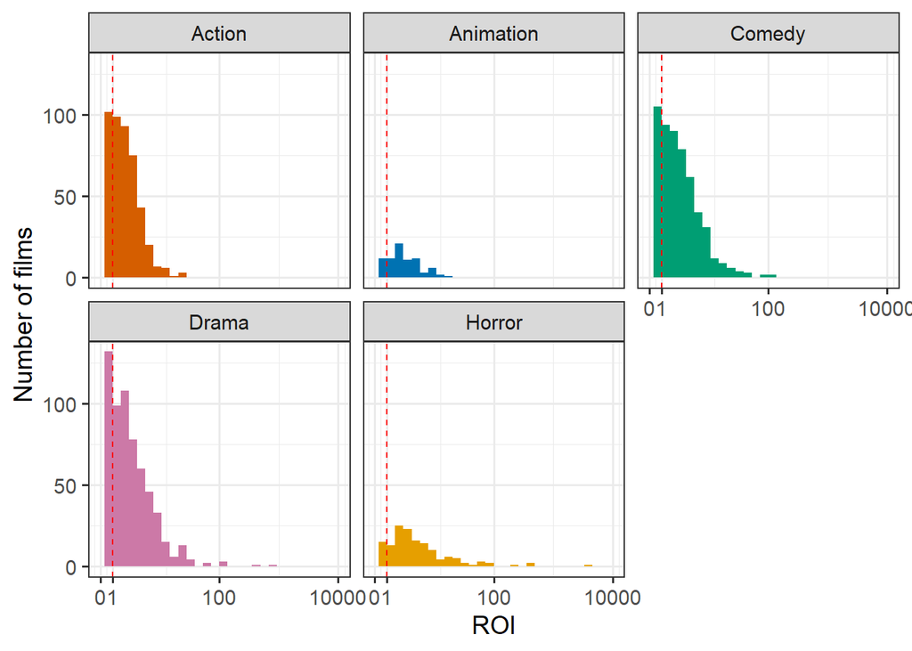

(d) ROI: Original films

Figure 1: Histograms showing distribution of budget costs and ROI for Original and Franchise films, faceted by film genre; only Meridian’s 5 focused genres are included

### Slate composition over time

We wanted to look at how the composition of the historical slate by genre has changed over time, with a specific focus on the genres Meridian is interested in.

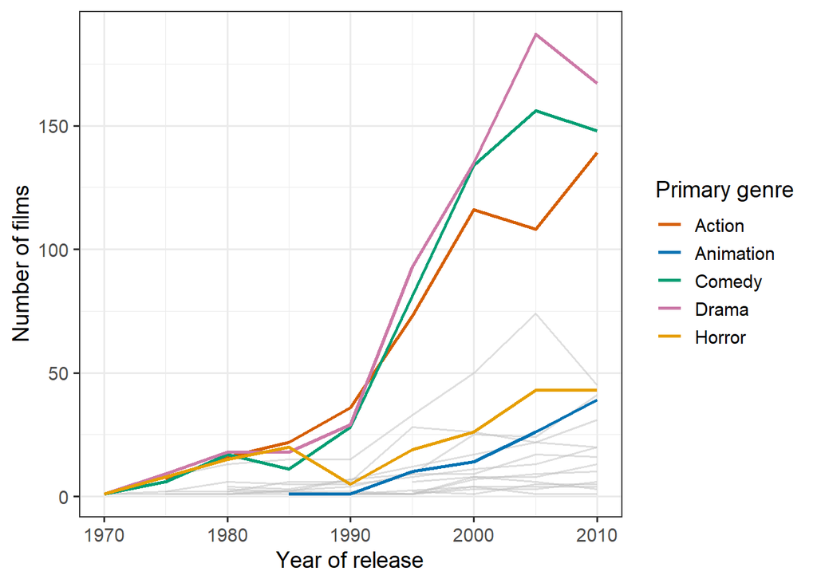

(a) Line chart showing trend in genre releases over time; the 5 genres Meridian is focused on are highlighted

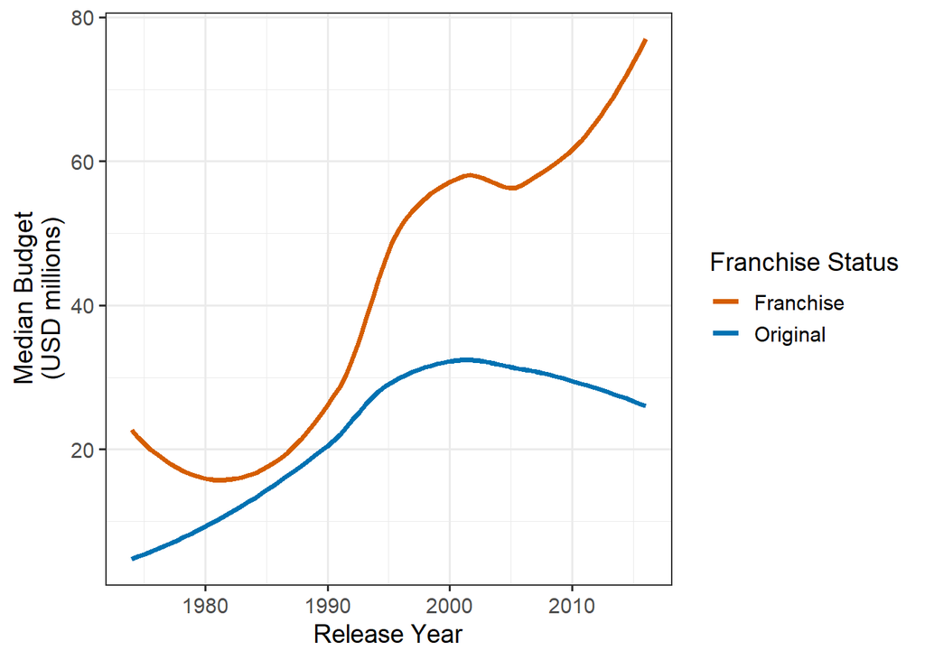

(b) Smoothed line plot showing median budget for Original vs Franchise films over the last ~50 years

Figure 2: Line charts showing changing composition of slate over time; film release dates have been aggregated into 5 year blocks to make trends more visible

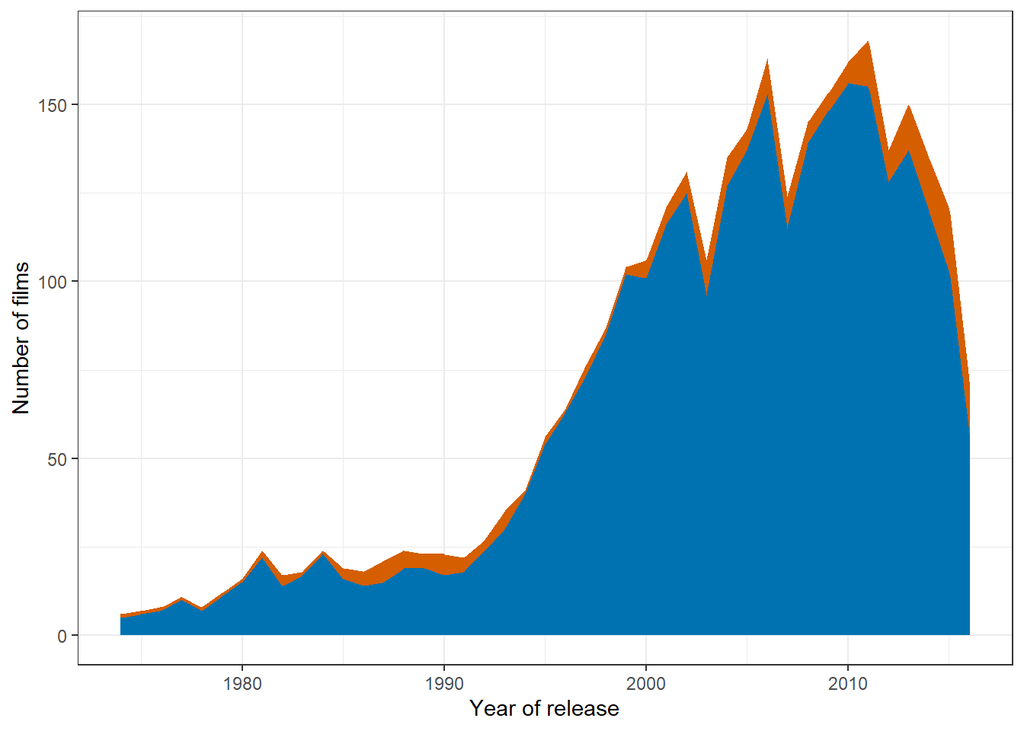

(a) Stacked area chart displaying actual numbers of films for each year

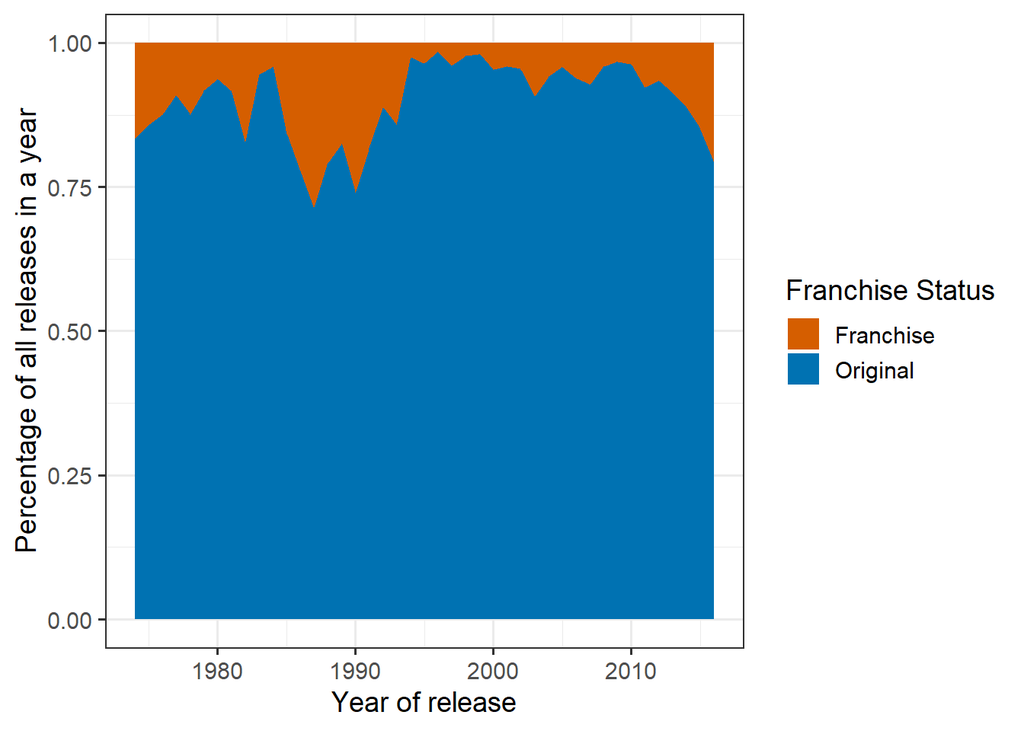

(b) Filled area chart showing franchise status as a percentage of all films released in a given year

Figure 3: Area charts showing the split between original and franchise films by year

### Summary

From the plots in this section, and given what we know about how films are coded (Note 1), we can draw some conclusions already.

The three genres that have consistently seen the most films released over the last 25+ years are Action, Comedy and Drama films (Figure 2 (a)), all of which Meridian is invested in.

There was a significant spike in the relative amount of Franchise films being released around 1990, which then completely flattened out prior to 2000 (Figure 3 (b)). With the recent trend towards a higher percentage of releases being Franchise movies, we should look towards that period in the 90s when developing our strategy for the next decade. This will be discussed more in Section 2.

## Task 2

Budget data are often skewed, and the median is often more meaningful than the mean when describing a budget for typical franchise and original categories. Here I will be using bootstraping to find 95% interval estimate for the difference in median budget between the two groups. As bootstraping simulates repeated samples from a population like the csv provided here, it can help us to describe the uncertainity in the data.

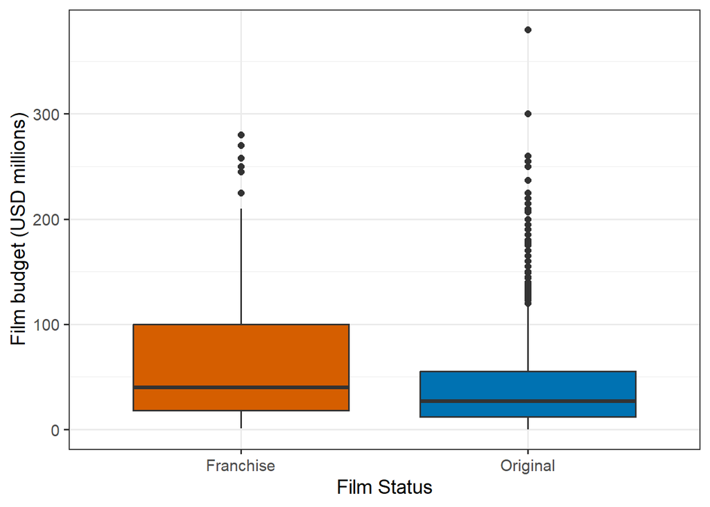

(a) Budget

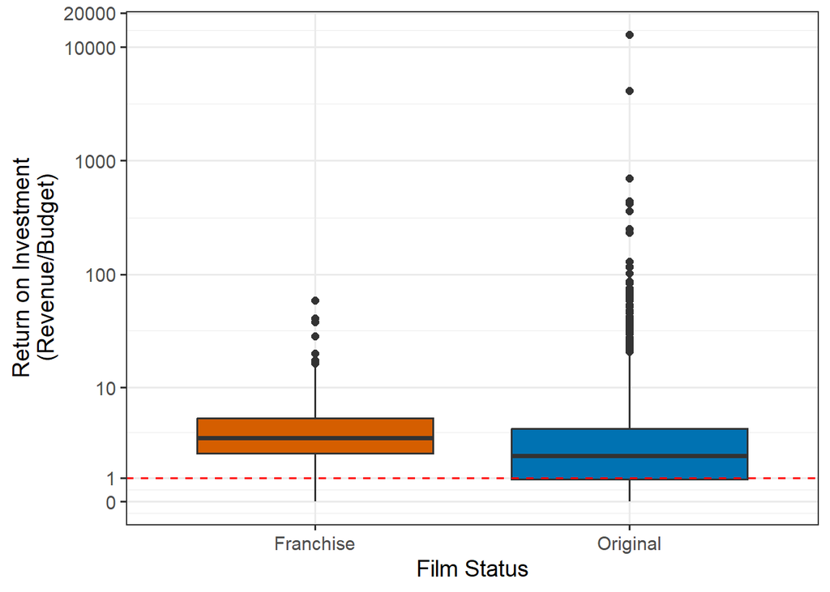

(b) ROI; dashed red line is at ROI = 1 i.e. films above the line made a profit, films below lost money

Figure 4: Boxplots showing distribution of budgets and Return on Investment (Revenue divided by Budget) for Original vs Franchise films

The Figure 4 (a) shows differnce in median of sequals and originals using a boxplot. The median budget of franchise is higher than the original (The data analysed here is from 1974 and later as discussed in Section 1) which raises the concern of the leadership about the budget. However in Figure 4 (b), the difference between ROI’s of both the categories shows a much needed aspect to increase the overall profits of the production house.

### Does it verify leadership concern?

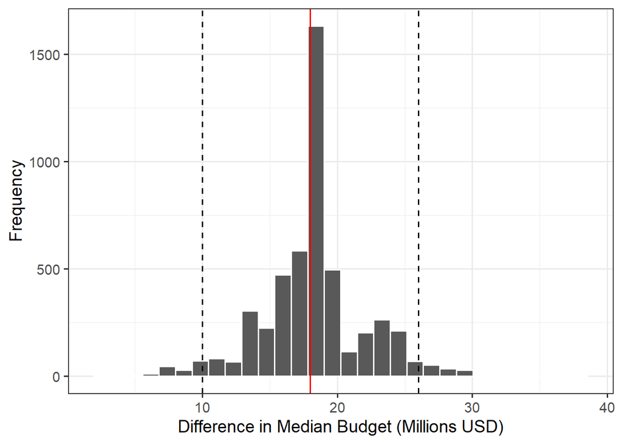

Figure 5: Bootstrap Distribution: Difference in Median Budgets, Franchise Median - Original Median (Solid line = observed, Dashed = 95% CI)

Figure 5 shows that the median difference is well above zero and similar to the point estimate which supports the concerns of the leadership of franchise slate absorbing much larger budgets than original slate.

Additionally from Section 2 Figure 4 (b), we can interpret that the originals have higher number of outliers that drastically increases the profits of the production houses but overall originals have a lower median ROI.

### Summary

However, as stated in Section 1, the sequels are much expensive to make than the originals and they have higher ROI than the originals, due to this reason the production houses are more inclined towards producing sequals as they have much better chance of creating profits than the originals. But from Section 2 Figure 4 (b), we can interpret that the originals have higher number of outliers that drastically increases the profits of the production houses. However, the median ROI in origianls is low hence producing originals seems risky.

### Advice

The advice to the leadership is to focus on original movies that have high potential such as the genre that have the most profitable originals with lower risk such as horror for 2017 and gradually increase the budget allocation for them while comparing the profits generated by both categories simultaniously and changing or refining the new original story selection strategy and finding a optimised allocation stratergy that maximises the profits for the company.

According to Section 1, Figure 1 (d) shows the ROI of originals in Meridian’s focus genre where less than 1 shows the movie was a flop or a disaster. The genre horror comes up at the top with second lowest flop rate and really high potential for a big profit.

Choosing more originals from horror genre in the slots for 2017 releases carefully and strategically, provides more room for higher profits and gradually trying and testing with different genre, creating an optimal budget allocation for movies can increase the profits with a high margin.

## Task 3

### Part 1: Production Budget Modelling

With the goal to construct a model that predicts an appropriate movie budget distribution, a competitor budget analysis was conducted as a credible reference point in line with industry standards. This was performed by sampling the budgeting model from Universal Pictures Studios, which is a direct industry competitor, and fitting a realistic probability model for Meridian to follow after similar data processing from previous analysis.

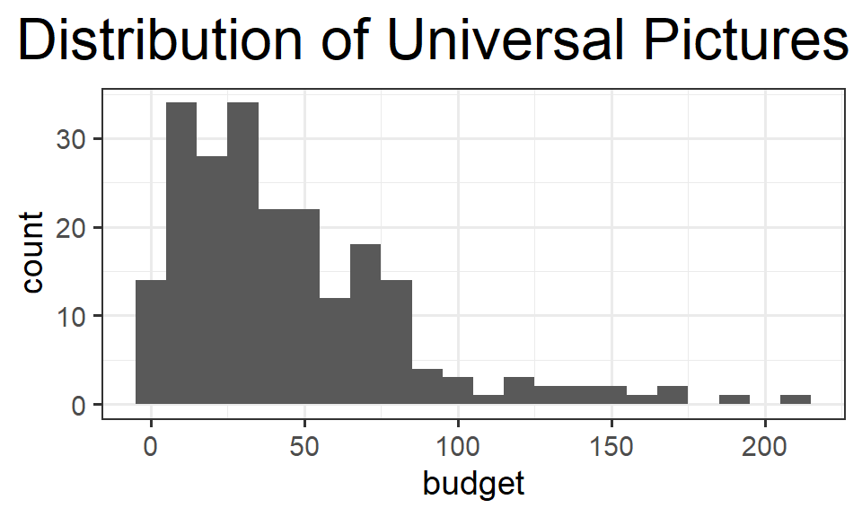

After data processing, the budget distribution is right skewed and only contain positive values. Therefore, Exponential, Gamma and Weibull distribution were selected for model evaluation.

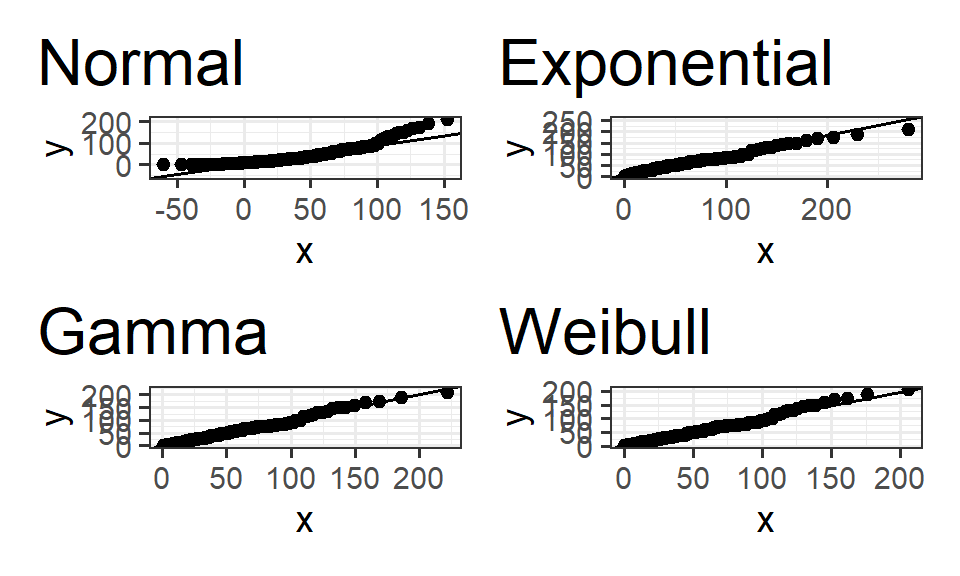

The QQ-plot indicates normal was the worst fit as the tails deviated the most from the reference line. The other models had a similar fit as the right tail have a similar distance from the reference line and most of the points overlap with the line.

| model | df | AIC |
| --- | --- | --- |
| budget_gamma | 2 | 2108 |
| budget_weibull | 2 | 2109 |
| budget_exp | 1 | 2126 |
| budget_normal | 2 | 2223 |

The Gamma model has lowest AIC, which paired with the fitting of the QQ-plot, suggests that it is the best at fitting budget data. However, the Weibull model would also be sufficient as the AIC is slightly larger than the gamma distribution by 1.

### Part 2: Downside Risk Analysis for Action Movie ROI

Action movies have been established as capital-intensive to produce, which can be proved as risky for budget investment in order to yield significant revenue. As a result, risk analysis into the bottom performing 25% movie ROI was performed across the entire film industry to model conservative target ROI to aim for,

The observed 25% percentile of Action Movie ROI was 0.89

| Calculation_method | Lower_Bound | Upper_bound |
| --- | --- | --- |
| Percentile bootstrap | 0.76 | 1 |
| Bootstrap SE (t) | 0.76 | 1 |

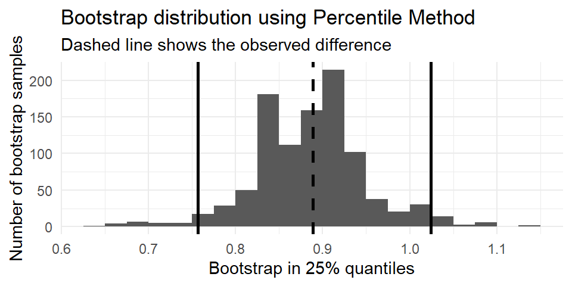

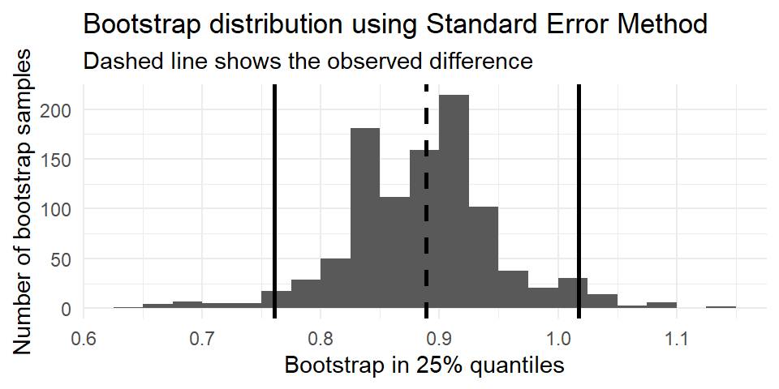

## Task 4

The new flop variable only has two possible outcomes, which means it can be modeled by a Bernoulli distribution, where the parameter p measures the probability that a move is a flop. Hence, logistic regression is the appropriate choice as the log function $\log\left(\frac{p_i}{1 - p_i}\right)$ ensures the predicted probabilities remain between 0 and 1. The linear regression is not suitable as it assumes outcomes are continuous and normally distributed, while the flop variable only takes 0 and 1. Poisson regression is also not suitable as it is used when the outcome is a count with no upper limit.

#### Frequentist Regression Equation

$$\log \left( \frac{\hat{p}_i}{1-\hat{p}_i} \right)
=
-2.241
- 0.678 \text{Animation}_i
- 0.327 \text{Comedy}_i
- 0.001 \text{Drama}_i
- 1.100 \text{Horror}_i
+ 1.411 \text{Original}_i
- 0.017 \text{log budget}_i
- 0.502 \text{cast size}_i$$

#### Bayesian Regression Equation

Weakly informative priors were placed on the log-odds scale: Normal(0, 1.5) for the intercept and Normal(0, 1) for each slope.

$$\log \left( \frac{\hat{p}_i}{1-\hat{p}_i} \right)
=
-2.17
- 0.63 \text{Animation}_i
- 0.30 \text{Comedy}_i
+ 0.02 \text{Drama}_i
- 1.05 \text{Horror}_i
+ 1.32 \text{Original}_i
- 0.02 \text{log budget}_i
- 0.50 \text{cast size}_i.$$

#### Confidence and Credible Interval Comparison

|  | flop |  |  | flop |  |
| --- | --- | --- | --- | --- | --- |
| Predictors | Odds Ratios | CI | p | Odds Ratios | CI (95%) |
| (Intercept) | 0.11 | 0.05 – 0.19 | **<0.001** |  |  |
| primary_genreAnimation | 0.51 | 0.28 – 0.87 | **0.017** | 0.53 | 0.31 – 0.89 |
| primary_genreComedy | 0.72 | 0.55 – 0.95 | **0.020** | 0.74 | 0.56 – 0.96 |
| primary_genreDrama | 1.00 | 0.77 – 1.30 | 0.996 | 1.02 | 0.79 – 1.33 |
| primary_genreHorror | 0.33 | 0.20 – 0.53 | **<0.001** | 0.35 | 0.21 – 0.55 |
| franchise status: Original | 4.10 | 2.28 – 8.16 | **<0.001** | 3.71 | 2.18 – 6.65 |
| log budget z | 0.98 | 0.88 – 1.10 | 0.763 | 0.98 | 0.88 – 1.10 |
| cast size z | 0.61 | 0.52 – 0.70 | **<0.001** | 0.61 | 0.52 – 0.71 |
| Intercept |  |  |  | 0.12 | 0.06 – 0.20 |
| Observations | 2155 |  |  | 2155 |  |
| R<sup>2</sup> Tjur | 0.057 |  |  | 0.053 |  |

Using the 5% significant level, franchise status, cast size, and the Animation, Comedy and Horror genres are significantly associated with the ods of a film flopping. The Drama genre and Log budget coefficient are not significantly associate with the odds of a movie flopping due to the p values being greater than the significant level after adjusting for other predictors.

The coefficient odds ratio (OR) interpretation as follows:

- Animation (frequentist OR = 0.51, Bayesian OR = 0.53): Animated films have about half the odds of flopping compared with Action films.
- Comedy (OR = 0.72, 0.74): Comedies have about 26–28% lower odds of flopping than Action films.
- Drama (OR = 1.00, 1.02): There is no meaningful difference in the odds of flopping between dramas and Action films.
- Horror (OR = 0.33, 0.35): Horror films have about 65–67% lower odds of flopping than Action films.
- Original (OR = 4.10, 3.71): Original films have about 3.7–4.1 times the odds of flopping compared with franchise films.
- Log budget (z) (OR = 0.98, 0.98): A one standard deviation increase in log budget is associated with almost no change in the odds of flopping.
- Cast size (z) (OR = 0.61, 0.61): A one standard deviation increase in cast size is associated with a 39% decrease of odds of flopping.

For original films, the 95% confidence interval for the odds ratio is [2.28, 8.16] and the 95% credible interval is [2.18, 6.65]. For cast size, the intervals are [0.52, 0.70] and [0.52, 0.71]. The cast size intervals are almost identical as the large sample size increases the weight of the data compared the weakly informative prior. The Original intervals differ more where the credible interval is narrower and closer to 1 because the Normal(0, 1) prior shrinks the coefficient. It is noteworthy that confidence intervals calculate the true OR in 95% of repeated samples while the credible interval uses the model, priors and data to calculate the posterior probability that the true OR lies within the interval.

#### Tested Posterior probability statement: Calculate the posterior probability that the odds ratio for log budget is greater than 1.2 (20% increase in the odds of a flop) or less than 0.8 (20% decrease).

Given the data and our prior, the probability that a 1 standard deviation increase in log budget increases the odds of a flop by more than 20% is 0.0005, and the probability that it decreases the odds by more than 20% is 0.

#### Confusion Matrix Analysis

```
          Actual
Predicted  Not flop Flop
  Not flop      756  136
  Flop          835  428
```

#### Sensitivity Analysis of Risk Threshold

| Threshold | Accuracy | Sensitivity | Specificity | Precision | F1 |
| --- | --- | --- | --- | --- | --- |
| 0.50 | 0.74 | 0.000 | 1.00 | NaN | NaN |
| 0.40 | 0.74 | 0.062 | 0.98 | 0.59 | 0.11 |
| 0.30 | 0.63 | 0.612 | 0.64 | 0.38 | 0.47 |
| 0.26 | 0.55 | 0.759 | 0.48 | 0.34 | 0.47 |
| 0.10 | 0.33 | 0.972 | 0.10 | 0.28 | 0.43 |

As only 26% of films were flops, a 0.5 threshold predicts no flops at all (sensitivity of 0), so the model is useless at this threshold because flops are not flagged. A threshold of 0.4 identifies only 6% of flops, which is too low given that approving a film that flops costs far more than rejecting a film that would have succeeded financially. Lowering the threshold to 0.1 catches 97% of flops but flags almost every film, however the specificity of 0.10 and accuracy of 0.33 would not approve enough safe films. At a threshold of 0.26, the model correctly identifies 76% of flops (sensitivity 0.76), but only 48% of non-flops are correctly cleared (specificity 0.48), and only 34% of flagged films actually flop (precision 0.34). Overall accuracy falls from 0.74 to 0.55, which is expected when prioritising the rarer outcome. A threshold of 0.3 gives a more even balance between sensitivity (0.61) and specificity (0.64), but 0.26 is preferred because its higher sensitivity catches more flops, where approving flops is the more expensive mistake.

#### Hypothetical Film Pitch Test

| pitch | primary_genre | franchise_status | budget | cast_size | Prob_flop | Lower | Upper | Flagged |
| --- | --- | --- | --- | --- | --- | --- | --- | --- |
| Pitch A | Action | Franchise | 2e+07 | 30 | 0.097 | 0.054 | 0.15 | Not flagged |
| Pitch B | Action | Original | 2e+07 | 30 | 0.279 | 0.240 | 0.32 | Flop risk |
| Pitch C | Comedy | Original | 2e+07 | 30 | 0.222 | 0.188 | 0.26 | Not flagged |

The model estimates the chance that a film will flop based on its genre, cast size, budget, and whether it is a franchise or an original. For each pitch, it gives a risk estimate and a range that we can be 95% confident contains the true flop risk. Since 26% of films in our data flopped, any pitch with a higher estimated risk is flagged. For example, pitch B is flagged with an above-average 28% chance of flopping, and should therefore not be greenlit. Pitch A has a low 10% chance of flopping and should be greenlit. Pitch C’s 22% chance is close to the average, so it should be greenlit with caution. Because our cut-off flags any film with above-average risk, Pitch C should still be reasonable to produce.

However, the model cannot reliably predict whether an individual film will flop. It only uses four factors, which explain a small part of why films flop. Other factors, such as script quality, casting star power and production quality are likely to matter more but are difficult to measure objectively. The model also predicts general patterns in flop trends, which means past trends are not indicative of future outcomes. Hence, it should be used as a supplementary factor alongside industry expertise to evaluate the film.